# Replication Code for Peer Grading

```r
formula_party <- belongparty ~ prox+edad+gender+education+sec+cellphone+internet+localidae
m7_party <- glm(formula_party, data = base_3, family = "binomial")

summary(m7_party)
```

```
##
## Call:
## glm(formula = formula_party, family = "binomial", data = base_3)
##
## Deviance Residuals:
##     Min       1Q   Median       3Q      Max
## -0.4031  -0.2067  -0.1763  -0.1463   3.1866
##
## Coefficients:
##             Estimate Std. Error z value Pr(>|z|)
## (Intercept) -3.17688    1.87648  -1.693   0.0905 .
## prox        -0.54096    0.64357  -0.841   0.4006
## edad         0.02288    0.01256   1.822   0.0685 .
## gender      -0.28839    0.39845  -0.724   0.4692
## education    0.05066    0.16230   0.312   0.7549
## sec          0.20696    0.20443   1.012   0.3114
## cellphone   -0.53125    0.47621  -1.116   0.2646
## internet    -0.26089    0.47315  -0.551   0.5814
## localidae   -0.83953    1.06675  -0.787   0.4313
## ---
## Signif. codes:  0 '***' 0.001 '**' 0.01 '*' 0.05 '.' 0.1 ' ' 1
##
## (Dispersion parameter for binomial family taken to be 1)
##
##     Null deviance: 272.73  on 1563  degrees of freedom
## Residual deviance: 265.38  on 1555  degrees of freedom
##   (36 observations deleted due to missingness)
## AIC: 283.38
##
## Number of Fisher Scoring iterations: 8
```

```r
formula_union <- belongunion ~ prox+edad+gender+education+sec+cellphone+internet+localidae
m8_union <- glm(formula_union, data = base_3, family = "binomial")

summary(m8_union)
```

```
##
## Call:
## glm(formula = formula_union, family = "binomial", data = base_3)
##
## Deviance Residuals:
##     Min       1Q   Median       3Q      Max
## -0.5913  -0.2087  -0.1457  -0.0996   3.3653
##
## Coefficients:
##             Estimate Std. Error z value Pr(>|z|)
## (Intercept) -3.15544    1.77111  -1.782  0.07481 .
## prox        -0.08062    0.31917  -0.253  0.80059
## edad         0.01962    0.01238   1.585  0.11301
## gender      -0.87261    0.42538  -2.051  0.04023 *
## education    0.40018    0.15301   2.615  0.00891 **
## sec         -0.02247    0.20565  -0.109  0.91299
## cellphone   -0.02575    0.52757  -0.049  0.96107
## internet    -0.99011    0.47767  -2.073  0.03819 *
## localidae    0.04041    1.06076   0.038  0.96961
## ---
## Signif. codes:  0 '***' 0.001 '**' 0.01 '*' 0.05 '.' 0.1 ' ' 1
##
## (Dispersion parameter for binomial family taken to be 1)
##
##     Null deviance: 288.75  on 1563  degrees of freedom
## Residual deviance: 260.38  on 1555  degrees of freedom
##   (36 observations deleted due to missingness)
## AIC: 278.38
##
## Number of Fisher Scoring iterations: 7
```

```r
formula_reli <- belongreligiousgroup ~ prox+edad+gender+education+sec+cellphone+internet+localidae
m9_reli <- glm(formula_reli, data = base_3, family = "binomial")

summary(m9_reli)
```

```
##
## Call:
## glm(formula = formula_reli, family = "binomial", data = base_3)
##
## Deviance Residuals:
##     Min       1Q   Median       3Q      Max
## -0.6758  -0.3505  -0.3092  -0.2693   2.7478
##
## Coefficients:
##              Estimate Std. Error z value Pr(>|z|)
## (Intercept) -2.612816   0.963706  -2.711   0.0067 **
## prox         0.039858   0.147279   0.271   0.7867
## edad         0.002608   0.007548   0.345   0.7297
## gender       0.315979   0.232825   1.357   0.1747
## education   -0.093923   0.102140  -0.920   0.3578
## sec         -0.219284   0.111566  -1.966   0.0494 *
## cellphone   -0.081484   0.275733  -0.296   0.7676
## internet    -0.427650   0.285818  -1.496   0.1346
## localidae    0.783482   0.380922   2.057   0.0397 *
## ---
## Signif. codes:  0 '***' 0.001 '**' 0.01 '*' 0.05 '.' 0.1 ' ' 1
##
## (Dispersion parameter for binomial family taken to be 1)
##
##     Null deviance: 637.45  on 1564  degrees of freedom
## Residual deviance: 625.56  on 1556  degrees of freedom
##   (35 observations deleted due to missingness)
## AIC: 643.56
##
## Number of Fisher Scoring iterations: 6
```

```r
# Seemingly Unrelated Regression by systemfit
# which result to trust, single regress or SUR?

sur_part2 <- systemfit(list(party = formula_party, union = formula_union, reli = formula_reli), data = base_3)
summary(sur_part2)
```

```
##
## systemfit results
## method: OLS
##
##           N   DF     SSR detRCov   OLS-R2 McElroy-R2
## system 4693 4666 130.523 1.5e-05 0.009715   0.007036
##
##          N   DF     SSR      MSE     RMSE       R2    Adj R2
## party 1564 1555 26.4216 0.016991 0.130351 0.004233 -0.000890
## union 1564 1555 27.9016 0.017943 0.133952 0.019698  0.014654
## reli  1565 1556 76.2002 0.048972 0.221296 0.007909  0.002808
##
## The covariance matrix of the residuals
##             party       union        reli
## party 0.016991360 0.000238771 0.002381169
## union 0.000238771 0.017943171 0.000969971
## reli  0.002381169 0.000969971 0.048452418
##
## The correlations of the residuals
##           party     union      reli
## party 1.0000000 0.0136747 0.0829889
## union 0.0136747 1.0000000 0.0328968
## reli  0.0829889 0.0328968 1.0000000
##
##
## OLS estimates for 'party' (equation 1)
## Model Formula: belongparty ~ prox + edad + gender + education + sec + cellphone +
##     internet + localidae
##
##                 Estimate   Std. Error  t value Pr(>|t|)
## (Intercept)  0.025696256  0.028981414  0.88665 0.375407
## prox        -0.003755706  0.004544695 -0.82639 0.408708
## edad         0.000381488  0.000216265  1.76398 0.077931 .
## gender      -0.005034495  0.006632230 -0.75910 0.447911
## education    0.000802285  0.002900956  0.27656 0.782156
## sec          0.003171853  0.003309569  0.95839 0.338016
## cellphone   -0.008269596  0.007724563 -1.07056 0.284534
## internet    -0.003754023  0.008335098 -0.45039 0.652494
## localidae   -0.008916255  0.013115703 -0.67982 0.496723
## ---
```

[output cut: 37 more lines]

```
## prox         0.001891072  0.007674463  0.24641 0.805397
## edad         0.000125153  0.000365197  0.34270 0.731871
## gender       0.015402088  0.011195344  1.37576 0.169094
## education   -0.004641461  0.004896596 -0.94790 0.343330
## sec         -0.011152392  0.005587892 -1.99581 0.046128 *
## cellphone   -0.003465234  0.013044203 -0.26565 0.790541
## internet    -0.020811423  0.014072965 -1.47882 0.139390
## localidae    0.045504970  0.022147637  2.05462 0.040082 *
## ---
## Signif. codes:  0 '***' 0.001 '**' 0.01 '*' 0.05 '.' 0.1 ' ' 1
##
## Residual standard error: 0.221296 on 1556 degrees of freedom
## Number of observations: 1565 Degrees of Freedom: 1556
## SSR: 76.200188 MSE: 0.048972 Root MSE: 0.221296
## Multiple R-Squared: 0.007909 Adjusted R-Squared: 0.002808
```

```r
# The last four formula are purely estimated by SUR
# Maybe replicate by regressing all formula separately?

formula_interestpoli <- interestpolitics ~ prox+edad+gender+education+sec+cellphone+internet+localidae

formula_interestelec <- interestelections ~ prox+edad+gender+education+sec+cellphone+internet+localidae

formula_discuss <- discusspolitics ~ prox+edad+gender+education+sec+cellphone+internet+localidae

formula_follow <- follownews ~ prox+edad+gender+education+sec+cellphone+internet+localidae

sur_part3 <- systemfit(list(interestpoli = formula_interestpoli, interestelec = formula_interestelec, discuss = formula_discuss, follow = formula_follow), data = base_3)
summary(sur_part3)
```

```
##
## systemfit results
## method: OLS
##
##           N   DF     SSR detRCov   OLS-R2 McElroy-R2
## system 6229 6193 34927.3 206.058 0.081075   0.036584
##
##                 N   DF     SSR     MSE    RMSE       R2   Adj R2
## interestpoli 1559 1550 9417.25 6.07564 2.46488 0.067252 0.062438
## interestelec 1558 1549 7905.80 5.10381 2.25916 0.090260 0.085562
## discuss      1553 1544 8296.62 5.37346 2.31807 0.094302 0.089610
## follow       1559 1550 9307.64 6.00493 2.45050 0.074970 0.070195
##
## The covariance matrix of the residuals
##              interestpoli interestelec discuss  follow
## interestpoli      6.07888      2.74492 3.37241 3.45475
## interestelec      2.74492      5.11949 2.59981 2.67575
## discuss           3.37241      2.59981 5.35618 3.95518
## follow            3.45475      2.67575 3.95518 5.96419
##
## The correlations of the residuals
##              interestpoli interestelec  discuss   follow
## interestpoli     1.000000     0.492038 0.591026 0.573747
## interestelec     0.492038     1.000000 0.496481 0.484228
## discuss          0.591026     0.496481 1.000000 0.699793
## follow           0.573747     0.484228 0.699793 1.000000
##
##
## OLS estimates for 'interestpoli' (equation 1)
## Model Formula: interestpolitics ~ prox + edad + gender + education + sec + cellphone +
##     internet + localidae
##
##                Estimate  Std. Error  t value   Pr(>|t|)
## (Intercept)  5.14528191  0.55045209  9.34737 < 2.22e-16 ***
## prox        -0.01490704  0.08598171 -0.17337  0.8623797
## edad         0.00245636  0.00410568  0.59828  0.5497383
## gender      -0.35356952  0.12565228 -2.81387  0.0049567 **
## education    0.37372288  0.05508529  6.78444 1.6531e-11 ***
## sec         -0.07748922  0.06271090 -1.23566  0.2167729
## cellphone   -0.18960966  0.14620390 -1.29689  0.1948637
```

[output cut: 63 more lines]

```
## prox         0.01464297  0.08514897  0.17197  0.8634845
## edad         0.00934364  0.00407093  2.29521  0.0218543 *
## gender      -0.23866503  0.12445772 -1.91764  0.0553403 .
## education    0.35439374  0.05437098  6.51807 9.6068e-11 ***
## sec         -0.04991123  0.06221222 -0.80227  0.4225176
## cellphone   -0.19075333  0.14483305 -1.31706  0.1880143
## internet    -0.41856027  0.15620957 -2.67948  0.0074517 **
## localidae   -0.55023766  0.24992402 -2.20162  0.0278391 *
## ---
## Signif. codes:  0 '***' 0.001 '**' 0.01 '*' 0.05 '.' 0.1 ' ' 1
##
## Residual standard error: 2.450496 on 1550 degrees of freedom
## Number of observations: 1559 Degrees of Freedom: 1550
## SSR: 9307.642661 MSE: 6.004931 Root MSE: 2.450496
## Multiple R-Squared: 0.07497 Adjusted R-Squared: 0.070195
```

I rewrite the Stata code to R here, and compare the results in R, Stata, and in the paper.

First, for the binomial and multinomial models (i.e., models starting with “m”), the R and Stata replication results are generally the same.

Third, the significance of the Figure 1’s results generally remain the same in replications.

Fourth, the Seemingly Unrelated Regression (SUR) results are quite different in R and Stata. Although still non-significant, the coefficients differ a lot. I attach all coefficients (in the paper and in the R replication) below.

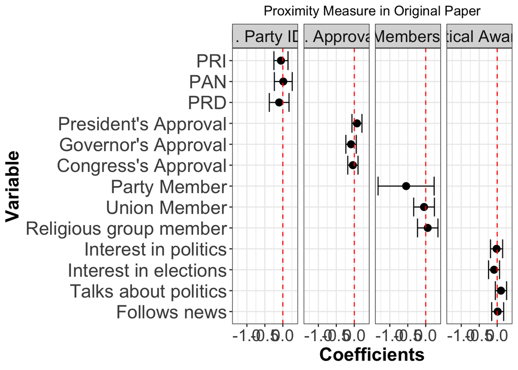

```r
results <- read.table(header=T, con <- textConnection('
IV  Coefficient StdError Coef_repli SE_repli    Model   Included    Variable Order
Proximity   -0.052  0.100   -0.055 0.101 1  1   PRI 13
Proximity  0.013    0.127   0.019 0.127 1   1   PAN 12
Proximity  -0.102  0.140    -0.102 0.141 1  1   PRD 11
Proximity  0.074    0.071   0.018 0.017 2   1   "President\'s Approval" 10
Proximity  -0.090   0.074   -0.023 0.017 2  1   "Governor\'s Approval" 9
Proximity  -0.039  0.073    0.008 0.016 2   1   "Congress\'s Approval" 8
Proximity  -0.546  0.398    -0.004 0.005 3  1   "Party Member" 7
Proximity  -0.047   0.147   -0.001 0.005 3  1   "Union Member" 6
Proximity  0.055  0.145 0.002 0.008 3   1   "Religious group member" 5
Proximity  -0.017  0.086  -0.015 0.086 4    1   "Interest in politics" 4
Proximity  -0.087   0.078   -0.081 0.079 4  1   "Interest in elections" 3
Proximity  0.105 0.080  0.109 0.081 4   1   "Talks about politics" 2
Proximity  0.014  0.085  0.015 0.085 4  1   "Follows news" 1
'))
close(con)

results$min<-results$Coefficient-(1.96*results$StdError)
results$max<-results$Coefficient+(1.96*results$StdError)
results$Color[results$Included==1]<-"black"
results$Color[results$Included==0]<-"white"

results$Model[results$Model==1]<-"1. Party ID"
results$Model[results$Model==2]<-"2. Approval"
results$Model[results$Model==3]<-"3. Membership"
results$Model[results$Model==4]<-"4. Political Awareness"

results$Variable <- factor(results$Variable, levels=results$Variable[order(results$Order)])

results$min_repli<-results$Coef_repli-(1.96*results$SE_repli)
results$max_repli<-results$Coef_repli+(1.96*results$SE_repli)

# a is the figure 1 with original data; I am still trying to combine them into one # so that comparison is possible
a<-ggplot(results, aes(y=reorder(Variable, Order), x = Coefficient)) +
#  scale_colour_gradient(low="white", high="black")+
  geom_point(size=3) +
  facet_grid( ~ Model)+
  geom_errorbarh(aes(xmin=min, xmax=max)) +
  geom_vline(xintercept = 0, linetype=2, color="red") +
  labs( x = "Coefficients", y = "Variable") +
  theme_bw()+
  theme(
    axis.title.x = element_text(face="bold", size=18),
    axis.title.y = element_text(face="bold", size=18, angle=90),
    axis.text.x  = element_text( size=16),
    strip.text.x = element_text(size=16),
    axis.text.y  = element_text( size=18),
    plot.title = element_text(hjust = 0.5)) +
  ggtitle("Proximity Measure in Original Paper")

a
```

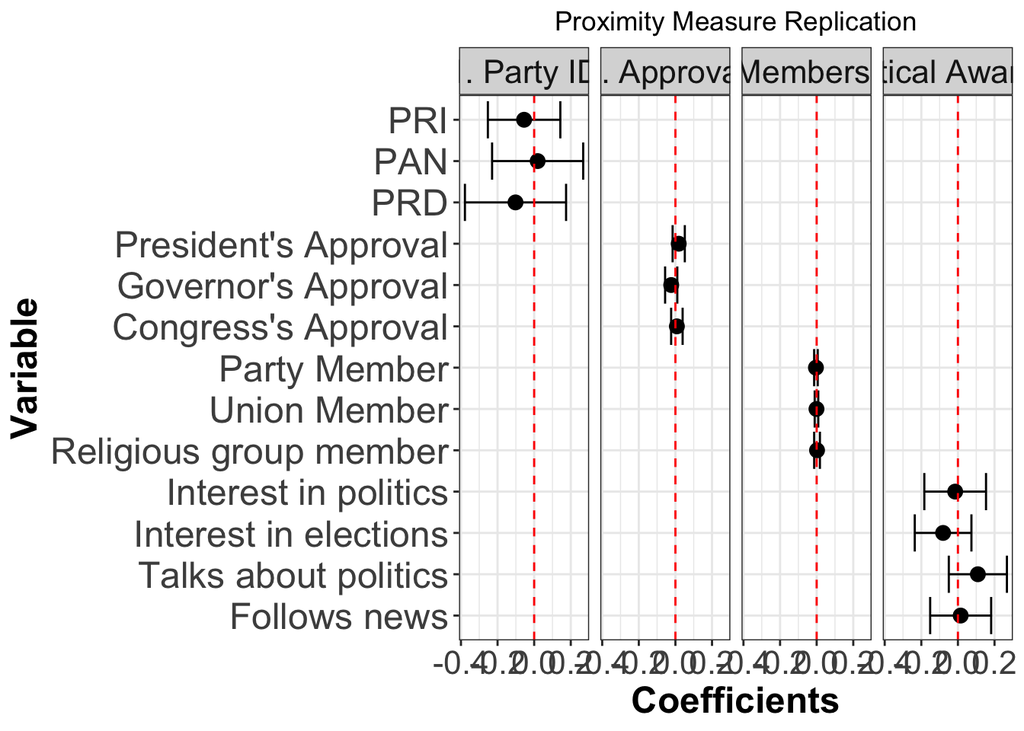

```r
# b is the figure 1 with replicated data
b<-ggplot(results, aes(y=reorder(Variable, Order), x = Coef_repli)) +
#  scale_colour_gradient(low="white", high="black")+
  geom_point(size=3) +
  facet_grid( ~ Model)+
  geom_errorbarh(aes(xmin=min_repli, xmax=max_repli))+
  geom_vline(xintercept = 0, linetype=2, color="red") +
  labs( x = "Coefficients", y = "Variable") +
  theme_bw()+
  theme(
    axis.title.x = element_text(face="bold", size=18),
    axis.title.y = element_text(face="bold", size=18, angle=90),
    axis.text.x  = element_text( size=16),
    strip.text.x = element_text(size=16),
    axis.text.y  = element_text( size=18),
    plot.title = element_text(hjust = 0.5)) +
  ggtitle("Proximity Measure Replication")

b
```

```r
# In this chunk I use distance instead of prox, and the new one for Figure 1 is presented as "c"
m1_3_multinom_dis <- multinom(partyid ~ distance+edad+gender+education+sec+cellphone+internet+localidae, data = base_3)
summary(m1_3_multinom_dis)
```

```
## Call:
## multinom(formula = partyid ~ distance + edad + gender + education +
##     sec + cellphone + internet + localidae, data = base_3)
##
## Coefficients:
##   (Intercept)     distance        edad      gender   education        sec
## 1   0.5284141  0.015317567 0.005898493  0.04846744 -0.27584566 -0.2113889
## 2   0.2498357 -0.026594614 0.002924409 -0.01883015 -0.04005697 -0.2176269
## 3   1.1625284  0.004233159 0.001618003  0.16741056 -0.25663329 -0.0977741
##    cellphone   internet     localidae
## 1 -0.2359282 -0.3170626  0.0007330051
## 2 -0.1328065 -0.4410206 -0.7446425158
## 3 -0.2833608 -0.3935745 -1.3074309763
##
## Std. Errors:
##   (Intercept)   distance        edad    gender  education        sec cellphone
## 1   0.6234181 0.01121510 0.004475565 0.1370962 0.06361012 0.06776067 0.1598818
## 2   1.1276632 0.02811711 0.006759861 0.2070302 0.08761381 0.10689906 0.2522212
## 3   0.9124718 0.01796760 0.005721228 0.1738436 0.07914896 0.08830688 0.2050028
##    internet localidae
## 1 0.1756480 0.3413421
## 2 0.2479200 0.8609261
## 3 0.2136644 0.6519070
##
## Residual Deviance: 3060.652
## AIC: 3114.652
```

```r
formula_presi_dis <- presidentialapp ~ distance+edad+gender+education+sec+cellphone+internet+localidae
m4_presi_dis <- glm(formula_presi_dis, data = base_3, family = "binomial")

summary(m4_presi_dis)
```

```
##
## Call:
## glm(formula = formula_presi_dis, family = "binomial", data = base_3)
##
## Deviance Residuals:
##     Min       1Q   Median       3Q      Max
## -1.5959  -1.0386  -0.9602   1.3014   1.5153
##
## Coefficients:
##              Estimate Std. Error z value Pr(>|z|)
## (Intercept) -0.900076   0.484233  -1.859   0.0631 .
## distance     0.015205   0.009613   1.582   0.1137
## edad         0.003297   0.003435   0.960   0.3371
## gender       0.209793   0.105085   1.996   0.0459 *
## education   -0.045062   0.046194  -0.976   0.3293
## sec         -0.038874   0.052997  -0.734   0.4632
## cellphone   -0.104966   0.122460  -0.857   0.3914
## internet    -0.057872   0.132714  -0.436   0.6628
## localidae    0.512195   0.285761   1.792   0.0731 .
## ---
## Signif. codes:  0 '***' 0.001 '**' 0.01 '*' 0.05 '.' 0.1 ' ' 1
##
## (Dispersion parameter for binomial family taken to be 1)
##
##     Null deviance: 2081.8  on 1526  degrees of freedom
## Residual deviance: 2056.5  on 1518  degrees of freedom
##   (73 observations deleted due to missingness)
## AIC: 2074.5
##
## Number of Fisher Scoring iterations: 4
```

```r
formula_gov_dis <- govapp ~ distance+edad+gender+education+sec+cellphone+internet+localidae
m5_gov_dis <- glm(formula_gov_dis, data = base_3, family = "binomial")

summary(m5_gov_dis)
```

```
##
## Call:
## glm(formula = formula_gov_dis, family = "binomial", data = base_3)
##
## Deviance Residuals:
##     Min       1Q   Median       3Q      Max
## -1.9980  -1.1894   0.7815   1.1351   1.4265
##
## Coefficients:
##              Estimate Std. Error z value Pr(>|z|)
## (Intercept) -0.642239   0.491300  -1.307   0.1911
## distance     0.019145   0.010262   1.866   0.0621 .
## edad        -0.003693   0.003405  -1.084   0.2782
## gender       0.146893   0.104430   1.407   0.1595
## education   -0.078260   0.045638  -1.715   0.0864 .
## sec          0.084594   0.052768   1.603   0.1089
## cellphone   -0.075767   0.122263  -0.620   0.5355
## internet     0.051222   0.130892   0.391   0.6956
## localidae    0.509151   0.302142   1.685   0.0920 .
## ---
## Signif. codes:  0 '***' 0.001 '**' 0.01 '*' 0.05 '.' 0.1 ' ' 1
##
## (Dispersion parameter for binomial family taken to be 1)
##
##     Null deviance: 2115.5  on 1530  degrees of freedom
## Residual deviance: 2075.1  on 1522  degrees of freedom
##   (69 observations deleted due to missingness)
## AIC: 2093.1
##
## Number of Fisher Scoring iterations: 4
```

```r
formula_congress_dis <- congressapp ~ distance+edad+gender+education+sec+cellphone+internet+localidae
m6_congress_dis <- glm(formula_congress_dis, data = base_3, family = "binomial")

summary(m6_congress_dis)
```

```
##
## Call:
## glm(formula = formula_congress_dis, family = "binomial", data = base_3)
##
## Deviance Residuals:
##     Min       1Q   Median       3Q      Max
## -1.3836  -0.9366  -0.8703   1.3953   1.6566
##
## Coefficients:
##              Estimate Std. Error z value Pr(>|z|)
## (Intercept) -0.963327   0.511496  -1.883  0.05965 .
## distance    -0.003477   0.010001  -0.348  0.72806
## edad        -0.002803   0.003610  -0.777  0.43736
## gender       0.150039   0.110366   1.359  0.17400
## education   -0.021757   0.047942  -0.454  0.64995
## sec         -0.107335   0.056226  -1.909  0.05626 .
## cellphone   -0.156386   0.129156  -1.211  0.22596
## internet     0.037583   0.138192   0.272  0.78565
## localidae    0.787927   0.305227   2.581  0.00984 **
## ---
## Signif. codes:  0 '***' 0.001 '**' 0.01 '*' 0.05 '.' 0.1 ' ' 1
##
## (Dispersion parameter for binomial family taken to be 1)
##
##     Null deviance: 1916.1  on 1473  degrees of freedom
## Residual deviance: 1897.9  on 1465  degrees of freedom
##   (126 observations deleted due to missingness)
## AIC: 1915.9
##
## Number of Fisher Scoring iterations: 4
```

```r
# Seemingly Unrelated Regression by systemfit
# which result to trust, single regress or SUR?

sur_part1_dis <- systemfit(list(presi = formula_presi_dis, gov = formula_gov_dis, congress = formula_congress_dis), method = "SUR", data = base_3)
summary(sur_part1_dis)
```

```
##
## systemfit results
## method: SUR
##
##           N   DF     SSR  detRCov   OLS-R2 McElroy-R2
## system 4532 4505 1071.21 0.007509 0.018291   0.006153
##
##             N   DF     SSR      MSE     RMSE       R2   Adj R2
## presi    1527 1518 366.826 0.241651 0.491580 0.016589 0.011406
## gov      1531 1522 371.453 0.244056 0.494020 0.025104 0.019980
## congress 1474 1465 332.934 0.227259 0.476717 0.012473 0.007081
##
## The covariance matrix of the residuals used for estimation
##             presi       gov  congress
## presi    0.241316 0.1178335 0.1122727
## gov      0.117834 0.2460283 0.0993869
## congress 0.112273 0.0993869 0.2278484
##
## The covariance matrix of the residuals
##             presi       gov  congress
## presi    0.241336 0.1178650 0.1123078
## gov      0.117865 0.2460705 0.0994396
## congress 0.112308 0.0994396 0.2278672
##
## The correlations of the residuals
##             presi      gov congress
## presi    1.000000 0.483629 0.478896
## gov      0.483629 1.000000 0.419934
## congress 0.478896 0.419934 1.000000
##
##
## SUR estimates for 'presi' (equation 1)
## Model Formula: presidentialapp ~ distance + edad + gender + education + sec +
##     cellphone + internet + localidae
##
##                 Estimate   Std. Error  t value Pr(>|t|)
## (Intercept)  0.287391195  0.115053420  2.49789 0.012598 *
## distance     0.003973838  0.002281434  1.74182 0.081743 .
## edad         0.000803062  0.000818816  0.98076 0.326868
## gender       0.050770287  0.025036810  2.02783 0.042752 *
```

[output cut: 43 more lines]

```
## distance    -0.000543726  0.002261100 -0.24047 0.8099999
## edad        -0.000566731  0.000806958 -0.70231 0.4826003
## gender       0.037790433  0.024768452  1.52575 0.1272883
## education   -0.006193253  0.010767697 -0.57517 0.5652649
## sec         -0.024613140  0.012516480 -1.96646 0.0494342 *
## cellphone   -0.034832357  0.028940953 -1.20357 0.2289517
## internet     0.007026839  0.031153979  0.22555 0.8215814
## localidae    0.183311995  0.069177250  2.64989 0.0081385 **
## ---
## Signif. codes:  0 '***' 0.001 '**' 0.01 '*' 0.05 '.' 0.1 ' ' 1
##
## Residual standard error: 0.476717 on 1465 degrees of freedom
## Number of observations: 1474 Degrees of Freedom: 1465
## SSR: 332.934473 MSE: 0.227259 Root MSE: 0.476717
## Multiple R-Squared: 0.012473 Adjusted R-Squared: 0.007081
```

```r
formula_party_dis <- belongparty ~ distance+edad+gender+education+sec+cellphone+internet+localidae
m7_party_dis <- glm(formula_party_dis, data = base_3, family = "binomial")

summary(m7_party_dis)
```

```
##
## Call:
## glm(formula = formula_party_dis, family = "binomial", data = base_3)
##
## Deviance Residuals:
##     Min       1Q   Median       3Q      Max
## -0.4059  -0.2067  -0.1776  -0.1481   3.1271
##
## Coefficients:
##              Estimate Std. Error z value Pr(>|z|)
## (Intercept) -3.803607   1.954390  -1.946   0.0516 .
## distance    -0.009831   0.042978  -0.229   0.8191
## edad         0.021408   0.012531   1.708   0.0876 .
## gender      -0.300034   0.398059  -0.754   0.4510
## education    0.038259   0.162712   0.235   0.8141
## sec          0.219811   0.203357   1.081   0.2797
## cellphone   -0.536122   0.476155  -1.126   0.2602
## internet    -0.203865   0.474097  -0.430   0.6672
## localidae   -0.450838   1.347212  -0.335   0.7379
## ---
## Signif. codes:  0 '***' 0.001 '**' 0.01 '*' 0.05 '.' 0.1 ' ' 1
##
## (Dispersion parameter for binomial family taken to be 1)
##
##     Null deviance: 272.73  on 1563  degrees of freedom
## Residual deviance: 266.49  on 1555  degrees of freedom
##   (36 observations deleted due to missingness)
## AIC: 284.49
##
## Number of Fisher Scoring iterations: 7
```

```r
formula_union_dis <- belongunion ~ distance+edad+gender+education+sec+cellphone+internet+localidae
m8_union_dis <- glm(formula_union_dis, data = base_3, family = "binomial")

summary(m8_union_dis)
```

```
##
## Call:
## glm(formula = formula_union_dis, family = "binomial", data = base_3)
##
## Deviance Residuals:
##     Min       1Q   Median       3Q      Max
## -0.6420  -0.2084  -0.1462  -0.0997   3.3695
##
## Coefficients:
##               Estimate Std. Error z value Pr(>|z|)
## (Intercept) -4.0675145  1.8377740  -2.213   0.0269 *
## distance    -0.0711031  0.0669941  -1.061   0.2885
## edad         0.0183548  0.0124096   1.479   0.1391
## gender      -0.8782621  0.4256693  -2.063   0.0391 *
## education    0.3853845  0.1531459   2.516   0.0119 *
## sec          0.0002438  0.2045361   0.001   0.9990
## cellphone   -0.0412950  0.5283548  -0.078   0.9377
## internet    -0.9130941  0.4796163  -1.904   0.0569 .
## localidae    1.0677992  1.2769481   0.836   0.4030
## ---
## Signif. codes:  0 '***' 0.001 '**' 0.01 '*' 0.05 '.' 0.1 ' ' 1
##
## (Dispersion parameter for binomial family taken to be 1)
##
##     Null deviance: 288.75  on 1563  degrees of freedom
## Residual deviance: 258.96  on 1555  degrees of freedom
##   (36 observations deleted due to missingness)
## AIC: 276.96
##
## Number of Fisher Scoring iterations: 8
```

```r
formula_reli_dis <- belongreligiousgroup ~ distance+edad+gender+education+sec+cellphone+internet+localidae
m9_reli_dis <- glm(formula_reli_dis, data = base_3, family = "binomial")

summary(m9_reli_dis)
```

```
##
## Call:
## glm(formula = formula_reli_dis, family = "binomial", data = base_3)
##
## Deviance Residuals:
##     Min       1Q   Median       3Q      Max
## -0.6513  -0.3514  -0.3100  -0.2667   2.7627
##
## Coefficients:
##              Estimate Std. Error z value Pr(>|z|)
## (Intercept) -2.349345   1.014941  -2.315   0.0206 *
## distance     0.012568   0.018388   0.683   0.4943
## edad         0.003156   0.007558   0.418   0.6762
## gender       0.321346   0.232867   1.380   0.1676
## education   -0.088367   0.102167  -0.865   0.3871
## sec         -0.228299   0.112243  -2.034   0.0420 *
## cellphone   -0.073384   0.275689  -0.266   0.7901
## internet    -0.448796   0.287477  -1.561   0.1185
## localidae    0.501852   0.548791   0.914   0.3605
## ---
## Signif. codes:  0 '***' 0.001 '**' 0.01 '*' 0.05 '.' 0.1 ' ' 1
##
## (Dispersion parameter for binomial family taken to be 1)
##
##     Null deviance: 637.45  on 1564  degrees of freedom
## Residual deviance: 625.18  on 1556  degrees of freedom
##   (35 observations deleted due to missingness)
## AIC: 643.18
##
## Number of Fisher Scoring iterations: 6
```

```r
# Seemingly Unrelated Regression by systemfit
# which result to trust, single regress or SUR?

sur_part2_dis <- systemfit(list(party = formula_party_dis, union = formula_union_dis, reli = formula_reli_dis), data = base_3)
summary(sur_part2_dis)
```

```
##
## systemfit results
## method: OLS
##
##           N   DF     SSR detRCov   OLS-R2 McElroy-R2
## system 4693 4666 130.507 1.5e-05 0.009843    0.00709
##
##          N   DF     SSR      MSE     RMSE       R2    Adj R2
## party 1564 1555 26.4324 0.016998 0.130378 0.003826 -0.001299
## union 1564 1555 27.8932 0.017938 0.133932 0.019994  0.014953
## reli  1565 1556 76.1810 0.048959 0.221268 0.008159  0.003060
##
## The covariance matrix of the residuals
##             party       union        reli
## party 0.016998301 0.000239078 0.002380069
## union 0.000239078 0.017937744 0.000978223
## reli  0.002380069 0.000978223 0.048439929
##
## The correlations of the residuals
##           party     union      reli
## party 1.0000000 0.0136916 0.0829443
## union 0.0136916 1.0000000 0.0331859
## reli  0.0829443 0.0331859 1.0000000
##
##
## OLS estimates for 'party' (equation 1)
## Model Formula: belongparty ~ distance + edad + gender + education + sec + cellphone +
##     internet + localidae
##
##                 Estimate   Std. Error  t value Pr(>|t|)
## (Intercept)  0.019673226  0.030599745  0.64292 0.520370
## distance    -0.000131725  0.000602983 -0.21846 0.827102
## edad         0.000366107  0.000216805  1.68865 0.091488 .
## gender      -0.005116767  0.006634246 -0.77127 0.440667
## education    0.000682631  0.002905599  0.23494 0.814289
## sec          0.003352852  0.003316626  1.01092 0.312211
## cellphone   -0.008339470  0.007728092 -1.07911 0.280706
## internet    -0.003316359  0.008368158 -0.39631 0.691933
## localidae   -0.004611347  0.018058694 -0.25535 0.798484
## ---
```

[output cut: 37 more lines]

```
## distance     0.000688603  0.001017896  0.67650 0.498826
## edad         0.000153375  0.000365988  0.41907 0.675222
## gender       0.015563652  0.011195030  1.39023 0.164658
## education   -0.004393948  0.004902823 -0.89621 0.370280
## sec         -0.011507190  0.005597962 -2.05560 0.039987 *
## cellphone   -0.003246671  0.013045816 -0.24887 0.803497
## internet    -0.021848766  0.014124137 -1.54691 0.122088
## localidae    0.030381815  0.030484502  0.99663 0.319098
## ---
## Signif. codes:  0 '***' 0.001 '**' 0.01 '*' 0.05 '.' 0.1 ' ' 1
##
## Residual standard error: 0.221268 on 1556 degrees of freedom
## Number of observations: 1565 Degrees of Freedom: 1556
## SSR: 76.180962 MSE: 0.048959 Root MSE: 0.221268
## Multiple R-Squared: 0.008159 Adjusted R-Squared: 0.00306
```

```r
# The last four formula are purely estimated by SUR
# Maybe replicate by regressing all formula separately?

formula_interestpoli_dis <- interestpolitics ~ distance+edad+gender+education+sec+cellphone+internet+localidae

formula_interestelec_dis <- interestelections ~ distance+edad+gender+education+sec+cellphone+internet+localidae

formula_discuss_dis <- discusspolitics ~ distance+edad+gender+education+sec+cellphone+internet+localidae

formula_follow_dis <- follownews ~ distance+edad+gender+education+sec+cellphone+internet+localidae

sur_part3_dis <- systemfit(list(interestpoli = formula_interestpoli_dis, interestelec = formula_interestelec_dis, discuss = formula_discuss_dis, follow = formula_follow_dis), data = base_3)
summary(sur_part3_dis)
```

```
##
## systemfit results
## method: OLS
##
##           N   DF     SSR detRCov   OLS-R2 McElroy-R2
## system 6229 6193 34831.7  202.57 0.083591   0.040168
##
##                 N   DF     SSR     MSE    RMSE       R2   Adj R2
## interestpoli 1559 1550 9386.11 6.05556 2.46080 0.070336 0.065538
## interestelec 1558 1549 7896.91 5.09807 2.25789 0.091284 0.086591
## discuss      1553 1544 8246.03 5.34069 2.31099 0.099825 0.095161
## follow       1559 1550 9302.65 6.00171 2.44984 0.075466 0.070694
##
## The covariance matrix of the residuals
##              interestpoli interestelec discuss  follow
## interestpoli      6.05051      2.76210 3.33526 3.43812
## interestelec      2.76210      5.11409 2.61546 2.68534
## discuss           3.33526      2.61546 5.31692 3.93424
## follow            3.43812      2.68534 3.93424 5.95560
##
## The correlations of the residuals
##              interestpoli interestelec  discuss   follow
## interestpoli     1.000000     0.496538 0.588042 0.572734
## interestelec     0.496538     1.000000 0.501573 0.486570
## discuss          0.588042     0.501573 1.000000 0.699154
## follow           0.572734     0.486570 0.699154 1.000000
##
##
## OLS estimates for 'interestpoli' (equation 1)
## Model Formula: interestpolitics ~ distance + edad + gender + education + sec +
##     cellphone + internet + localidae
##
##                Estimate  Std. Error  t value   Pr(>|t|)
## (Intercept)  4.66240648  0.58049455  8.03178 1.7764e-15 ***
## distance    -0.02597960  0.01141866 -2.27519  0.0230307 *
## edad         0.00158679  0.00410430  0.38662  0.6990926
## gender      -0.35906593  0.12537447 -2.86395  0.0042403 **
## education    0.36533815  0.05503815  6.63791 4.3868e-11 ***
## sec         -0.06557634  0.06269867 -1.04590  0.2957718
## cellphone   -0.19716643  0.14589730 -1.35141  0.1767627
```

[output cut: 63 more lines]

```
## distance    -0.01055680  0.01133058 -0.93171  0.3516318
## edad         0.00904833  0.00407651  2.21962  0.0265885 *
## gender      -0.24071352  0.12438537 -1.93522  0.0531445 .
## education    0.35143698  0.05441439  6.45853 1.4113e-10 ***
## sec         -0.04575333  0.06230208 -0.73438  0.4628290
## cellphone   -0.19369239  0.14476422 -1.33799  0.1810975
## internet    -0.40592811  0.15667069 -2.59096  0.0096606 **
## localidae   -0.33425472  0.34341154 -0.97334  0.3305383
## ---
## Signif. codes:  0 '***' 0.001 '**' 0.01 '*' 0.05 '.' 0.1 ' ' 1
##
## Residual standard error: 2.449839 on 1550 degrees of freedom
## Number of observations: 1559 Degrees of Freedom: 1550
## SSR: 9302.649093 MSE: 6.001709 Root MSE: 2.449839
## Multiple R-Squared: 0.075466 Adjusted R-Squared: 0.070694
```